# ElectionData

Editor: Dar Lador, she codes;

```python
%matplotlib inline
from pandas import *
import matplotlib as mpl
import numpy as np
#from datetime import datetime
mpl.rc('figure', figsize=(12, 6))
set_option('display.notebook_repr_html', False)
set_option('display.max_columns', 18)
months = {'JAN' : 1, 'FEB' : 2, 'MAR' : 3, 'APR' : 4, 'MAY' : 5, 'JUN' : 6,
          'JUL' : 7, 'AUG' : 8, 'SEP' : 9, 'OCT': 10, 'NOV': 11, 'DEC' : 12}
of_interest = ['Obama, Barack', 'Romney, Mitt', 'Santorum, Rick',
               'Paul, Ron', 'Gingrich, Newt']
parties = {
  'Bachmann, Michelle': 'Republican',
  'Romney, Mitt': 'Republican',
  'Obama, Barack': 'Democrat',
  "Roemer, Charles E. 'Buddy' III": 'Reform',
  'Pawlenty, Timothy': 'Republican',
  'Johnson, Gary Earl': 'Libertarian',
  'Paul, Ron': 'Republican',
  'Santorum, Rick': 'Republican',
  'Cain, Herman': 'Republican',
  'Gingrich, Newt': 'Republican',
  'McCotter, Thaddeus G': 'Republican',
  'Huntsman, Jon': 'Republican',
  'Perry, Rick': 'Republican'
 }
```

### *she codes;* notes

If you try to run `fec = read_csv('P00000001-ALL.txt')` you'll get a `DtypeWarning`, which is a `low_memory` warning. We get it because guessing dtypes for each column is very memory demanding. Pandas tries to determine what dtype to set by analyzing the data in each column. Determining what dtype can only truly be done once the file is read. This means nothing can really be parsed before the whole file is read unless you risk having to change the dtype of that column when you read the last value. For example, consider a file which has a column called `ID`, with milions of rows where the `ID` is always numbers. Since pandas cannot know it is only numbers, it will probably keep it as the original strings until it has read the whole file. If we add something like `dtype={'ID':pandas.np.int64}` to the `read_csv()`, Pandas will read the `ID` column as numbers.

In practice, we can fix this problem: 1st, write:

```
fec = read_csv('P00000001-ALL.txt')
```

It wont read the whole file and will return a low_memory warning. Then, write:

```
fec.dtypes
```

It returns the dtypes of each column, for example:

```
'''
cmte_id               object
cand_id               object
cand_nm               object
contb_receipt_amt    float64
...                   ...
file_num               int64
dtype: object
'''
```

Then, you just need to add all of them to a dictionary as I did below:

```python
fec = read_csv('P00000001-ALL.txt', dtype={'contb_receipt_amt': np.float64, 'file_num': np.int64, 'cmte_id': np.object,
                                           'cand_id': np.object, 'cand_nm': np.object, 'contbr_city': np.object,
                                           'contbr_st': np.object, 'contbr_zip': np.object, 'contbr_employer': np.object,
                                           'contbr_occupation': np.object, 'contb_receipt_dt': np.object, 'memo_cd': np.object,
                                           'receipt_desc': np.object, 'memo_text': np.object, 'form_tp':np.object})
```

```python
fec.info(verbose=True) #summery view
```

```
<class 'pandas.core.frame.DataFrame'>
RangeIndex: 536041 entries, 0 to 536040
Data columns (total 16 columns):
cmte_id              536041 non-null object
cand_id              536041 non-null object
cand_nm              536041 non-null object
contbr_nm            536041 non-null object
contbr_city          536026 non-null object
contbr_st            536040 non-null object
contbr_zip           535973 non-null object
contbr_employer      525088 non-null object
contbr_occupation    530520 non-null object
contb_receipt_amt    536041 non-null float64
contb_receipt_dt     536041 non-null object
receipt_desc         8479 non-null object
memo_cd              49718 non-null object
memo_text            52740 non-null object
form_tp              536041 non-null object
file_num             536041 non-null int64
dtypes: float64(1), int64(1), object(14)
memory usage: 65.4+ MB
```

```python
parties    # dictionary
```

```
{'Bachmann, Michelle': 'Republican',
 'Cain, Herman': 'Republican',
 'Gingrich, Newt': 'Republican',
 'Huntsman, Jon': 'Republican',
 'Johnson, Gary Earl': 'Libertarian',
 'McCotter, Thaddeus G': 'Republican',
 'Obama, Barack': 'Democrat',
 'Paul, Ron': 'Republican',
 'Pawlenty, Timothy': 'Republican',
 'Perry, Rick': 'Republican',
 "Roemer, Charles E. 'Buddy' III": 'Reform',
 'Romney, Mitt': 'Republican',
 'Santorum, Rick': 'Republican'}
```

```python
fec.cand_nm #candidate name
```

```
0         Bachmann, Michelle
1         Bachmann, Michelle
2         Bachmann, Michelle
3         Bachmann, Michelle
4         Bachmann, Michelle
5         Bachmann, Michelle
6         Bachmann, Michelle
7         Bachmann, Michelle
8         Bachmann, Michelle
9         Bachmann, Michelle
10        Bachmann, Michelle
11        Bachmann, Michelle
12        Bachmann, Michelle
13        Bachmann, Michelle
14        Bachmann, Michelle
```

[output cut: 47 more lines]

```python
fec['party'] = fec.cand_nm.map(parties)  # map can take dictionary, series...
                                         # Alternatively, use list comprehension: [parties[x] for x in fec.cand_nm]
```

Read about map [here](http://pandas.pydata.org/pandas-docs/stable/generated/pandas.Series.map.html).

```python
fec.ix[0]    # A single record.
```

```
cmte_id                       C00410118
cand_id                       P20002978
cand_nm              Bachmann, Michelle
contbr_nm               HARVEY, WILLIAM
contbr_city                      MOBILE
contbr_st                            AL
contbr_zip                    366010290
contbr_employer                 RETIRED
contbr_occupation               RETIRED
contb_receipt_amt                   250
contb_receipt_dt              20-JUN-11
receipt_desc                        NaN
memo_cd                             NaN
memo_text                           NaN
form_tp                           SA17A
file_num                         736166
party                        Republican
Name: 0, dtype: object
```

```python
fec.party.value_counts()   # Doing it high level way using histogram. (a histogram of a Series)
```

```
Democrat       292400
Republican     237575
Reform           5364
Libertarian       702
Name: party, dtype: int64
```

```python
np.unique(fec.party)
```

```
array(['Democrat', 'Libertarian', 'Reform', 'Republican'], dtype=object)
```

```python
fec.groupby('party')['contb_receipt_amt'].sum()
```

```
party
Democrat       8.105758e+07
Libertarian    4.132769e+05
Reform         3.390338e+05
Republican     1.192255e+08
Name: contb_receipt_amt, dtype: float64
```

```python
fec.groupby(['party', 'contb_receipt_dt'])['contb_receipt_amt'].sum()   # Not a python date object.
```

```
party       contb_receipt_dt
Democrat    01-AUG-11            175281.00
            01-DEC-11            651532.82
            01-JAN-12             58098.80
            01-JUL-11            165961.00
            01-JUN-11            145459.00
            01-MAY-11             82644.00
            01-NOV-11            122529.87
            01-OCT-11            148977.00
            01-SEP-11            403297.62
            02-AUG-11            164510.11
            02-DEC-11            216056.96
            02-JAN-12             89743.60
            02-JUL-11             17105.00
            02-JUN-11            422453.00
            02-MAY-11            396675.00
            02-NOV-11            147183.81
            02-OCT-11             62605.62
            02-SEP-11            137948.41
            03-AUG-11            147053.02
            03-DEC-11             81304.02
            03-JAN-12             87406.97
            03-JUL-11              5982.00
            03-JUN-11            320176.20
            03-MAY-11            261819.11
            03-NOV-11            119304.56
            03-OCT-11            363061.02
            03-SEP-11             45598.00
            04-APR-11            640235.12
            04-AUG-11            598784.23
            04-DEC-11             72795.10
                                   ...
Republican  29-AUG-11            941769.23
            29-DEC-11            428501.42
            29-JAN-11               750.00
            29-JAN-12             75220.02
            29-JUL-11            233423.35
            29-JUN-11           1340704.29
            29-MAR-11             38875.00
            29-MAY-11              8363.20
```

[output cut: 8 more lines]

```
            30-JUN-11           2744932.63
            30-MAR-11             50240.00
            30-MAY-11             17803.60
            30-NOV-11            809014.83
            30-OCT-11             43913.16
            30-SEP-11           4886331.76
            31-AUG-11           1017735.02
            31-DEC-11           1094376.72
            31-JAN-11              6000.00
            31-JAN-12            869890.41
            31-JUL-11             12781.02
            31-MAR-11             62475.00
            31-MAY-11            301339.80
            31-OCT-11            734601.83
Name: contb_receipt_amt, dtype: float64
```

```python
fec.contb_receipt_dt[0]
```

```
'20-JUN-11'
```

```python
print(months)
```

```
{'APR': 4, 'MAR': 3, 'OCT': 10, 'MAY': 5, 'JAN': 1, 'DEC': 12, 'JUL': 7, 'AUG': 8, 'FEB': 2, 'SEP': 9, 'NOV': 11, 'JUN': 6}
```

### *she codes;* notes

As I toled you, this is an old video. You don't need to import datetime and write a fuction that convert strings to dates. You just need to write

```
fec['contb_receipt_dt'] = to_datetime(fec['contb_receipt_dt'], format='%d-%b-%y')
```

```python
'''
This function is useless!
'''

def convert_date(val):    # function to convert date to python's date object.
    d, m, y = val.split('-')
    m = months[m]
    return datetime(int ('20' + y), m, int(d))

fec.contb_receipt_dt   # output a list of date (not yet in python objects).
fec['contb_receipt_dt'] = fec.contb_receipt_dt.map(convert_date)
```

```python
fec.contb_receipt_dt[0]
```

```
Timestamp('2011-06-20 00:00:00')
```

```python
fec.groupby(['party', 'contb_receipt_dt'])['contb_receipt_amt'].sum() # Same as above, however, date converted to python object.
```

```
party       contb_receipt_dt
Democrat    2011-04-04           640235.12
            2011-04-05           307641.00
            2011-04-06           247542.59
            2011-04-07           252336.00
            2011-04-08           295452.00
            2011-04-09           105879.00
            2011-04-10           100373.00
            2011-04-11           360728.00
            2011-04-12           405160.46
            2011-04-13           382836.33
            2011-04-14           306643.50
            2011-04-15           408377.00
            2011-04-16            82658.00
            2011-04-17            70802.00
            2011-04-18           501971.37
            2011-04-19           304874.00
            2011-04-20           314540.11
            2011-04-21           315618.00
            2011-04-22           295464.45
            2011-04-23            34829.00
            2011-04-24            37100.00
            2011-04-25           447282.00
            2011-04-26           600960.50
            2011-04-27           188595.00
            2011-04-28           677041.36
            2011-04-29           294709.00
            2011-04-30            95582.00
            2011-05-01            82644.00
            2011-05-02           396675.00
            2011-05-03           261819.11
                                   ...
Republican  2012-01-02           114037.13
            2012-01-03           155803.62
            2012-01-04           577733.61
            2012-01-05           451065.98
            2012-01-06           262798.46
            2012-01-07           148145.58
            2012-01-08            84342.84
            2012-01-09           501931.44
```

[output cut: 8 more lines]

```
            2012-01-18           888681.17
            2012-01-19          1066250.23
            2012-01-20           401298.03
            2012-01-21           374261.81
            2012-01-22           507168.71
            2012-01-23           645477.15
            2012-01-24           462233.66
            2012-01-25           416931.39
            2012-01-26           256406.86
            2012-01-27           368441.82
            2012-01-28            82775.80
            2012-01-29            75220.02
            2012-01-30           255204.80
            2012-01-31           869890.41
Name: contb_receipt_amt, dtype: float64
```

```python
by_date = fec.groupby(['party', 'contb_receipt_dt'])['contb_receipt_amt'].sum()
```

```python
by_date.unstack('party').info(verbose=True)   # Indexes are dates. Columns are political parties.
```

```
<class 'pandas.core.frame.DataFrame'>
DatetimeIndex: 376 entries, 2011-01-01 to 2012-01-31
Data columns (total 4 columns):
Democrat       303 non-null float64
Libertarian    190 non-null float64
Reform         314 non-null float64
Republican     376 non-null float64
dtypes: float64(4)
memory usage: 14.7 KB
```

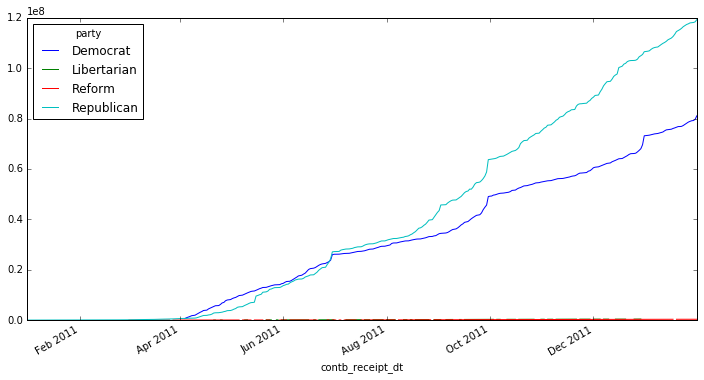

```python
by_date.unstack('party').cumsum().plot()
```

```python
s = by_date.unstack('party')[-5:].stack() #only the last 5 indexes
```

```python
s    # Note the inner level indexes. Not every date has 3 parties. Top level indexes are dates. stack() makes 1 dimensional.
     # Labels propagated down for all 3 observations: political parties.
```

```
contb_receipt_dt  party
2012-01-27        Democrat       305785.47
                  Reform           3176.37
                  Republican     368441.82
2012-01-28        Democrat       235492.85
                  Reform            175.00
                  Republican      82775.80
2012-01-29        Democrat        93177.00
                  Reform            200.00
                  Republican      75220.02
2012-01-30        Democrat       435921.72
                  Reform            130.00
                  Republican     255204.80
2012-01-31        Democrat      1418410.31
                  Reform            150.00
                  Republican     869890.41
dtype: float64
```

```python
set_option('display.notebook_repr_html', False)  # turn off html, i.e., without table.
s.unstack()    # unstack() 2 dimensional.
```

```
party               Democrat   Reform  Republican
contb_receipt_dt
2012-01-27         305785.47  3176.37   368441.82
2012-01-28         235492.85   175.00    82775.80
2012-01-29          93177.00   200.00    75220.02
2012-01-30         435921.72   130.00   255204.80
2012-01-31        1418410.31   150.00   869890.41
```

```python
s.unstack().stack()  # 2 dimensional to 1 dimensional
```

```
contb_receipt_dt  party
2012-01-27        Democrat       305785.47
                  Reform           3176.37
                  Republican     368441.82
2012-01-28        Democrat       235492.85
                  Reform            175.00
                  Republican      82775.80
2012-01-29        Democrat        93177.00
                  Reform            200.00
                  Republican      75220.02
2012-01-30        Democrat       435921.72
                  Reform            130.00
                  Republican     255204.80
2012-01-31        Democrat      1418410.31
                  Reform            150.00
                  Republican     869890.41
dtype: float64
```

```python
df = s.unstack('party')   # data frame
```

```python
s.unstack('contb_receipt_dt')
```

```
contb_receipt_dt  2012-01-27  2012-01-28  2012-01-29  2012-01-30  2012-01-31
party
Democrat           305785.47   235492.85    93177.00   435921.72  1418410.31
Reform               3176.37      175.00      200.00      130.00      150.00
Republican         368441.82    82775.80    75220.02   255204.80   869890.41
```

```python
concat([df, df], axis=1, keys=['A', 'B'])  # join 2 copies of data frame.
                                           # standard hierarchical indexing stuff.
```

```
                           A                               B           \
party               Democrat   Reform Republican    Democrat   Reform
contb_receipt_dt
2012-01-27         305785.47  3176.37  368441.82   305785.47  3176.37
2012-01-28         235492.85   175.00   82775.80   235492.85   175.00
2012-01-29          93177.00   200.00   75220.02    93177.00   200.00
2012-01-30         435921.72   130.00  255204.80   435921.72   130.00
2012-01-31        1418410.31   150.00  869890.41  1418410.31   150.00


party            Republican
contb_receipt_dt
2012-01-27        368441.82
2012-01-28         82775.80
2012-01-29         75220.02
2012-01-30        255204.80
2012-01-31        869890.41
```

```python
concat([df, df], axis=1, keys=['A', 'B'])['A']   # select out columns by the first key 'A'. Or select out the 'B' group.conc
```

```
party               Democrat   Reform  Republican
contb_receipt_dt
2012-01-27         305785.47  3176.37   368441.82
2012-01-28         235492.85   175.00    82775.80
2012-01-29          93177.00   200.00    75220.02
2012-01-30         435921.72   130.00   255204.80
2012-01-31        1418410.31   150.00   869890.41
```

```python
concat([df, df], axis=1, keys=['A', 'B']).stack('party')
```

```
                                      A           B
contb_receipt_dt party
2012-01-27       Democrat     305785.47   305785.47
                 Reform         3176.37     3176.37
                 Republican   368441.82   368441.82
2012-01-28       Democrat     235492.85   235492.85
                 Reform          175.00      175.00
                 Republican    82775.80    82775.80
2012-01-29       Democrat      93177.00    93177.00
                 Reform          200.00      200.00
                 Republican    75220.02    75220.02
2012-01-30       Democrat     435921.72   435921.72
                 Reform          130.00      130.00
                 Republican   255204.80   255204.80
2012-01-31       Democrat    1418410.31  1418410.31
                 Reform          150.00      150.00
                 Republican   869890.41   869890.41
```

```python
concat([df, df], axis=1, keys=['A', 'B']).stack(0)  # The group indexes have no labels.
```

```
party                 Democrat   Reform  Republican
contb_receipt_dt
2012-01-27       A   305785.47  3176.37   368441.82
                 B   305785.47  3176.37   368441.82
2012-01-28       A   235492.85   175.00    82775.80
                 B   235492.85   175.00    82775.80
2012-01-29       A    93177.00   200.00    75220.02
                 B    93177.00   200.00    75220.02
2012-01-30       A   435921.72   130.00   255204.80
                 B   435921.72   130.00   255204.80
2012-01-31       A  1418410.31   150.00   869890.41
                 B  1418410.31   150.00   869890.41
```

```python
result = fec.groupby(['cand_nm', 'contbr_occupation'])['contb_receipt_amt'].sum()
# Top contributors to candidates by occupation.
```